# Statistical Computing

School of Economics and Management  
Beihang University  
http://yanfei.site

## Why numerical linear algebra?

- Difference between linear algebra and **applied** linear algebra.
- Think about linear algebra in Statistics.
- In curve fitting.
- In image processing.
- In signal processing.
- etc.

## We need to know numerical techniques!

## Eigenanalysis

- In general, a matrix acts on a vector by changing both its magnitude and its direction.
- However, a matrix may act on certain vectors by changing only their magnitude, and leaving their direction unchanged (or reversing it).
  - these vectors are the eigenvectors of the matrix
  - the scaling factor is the eigenvalue.

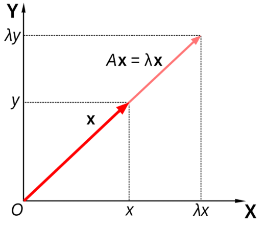

## Example

- Think about the linear transformation \(\mathbf{y} = \mathbf{A}\mathbf{x}\), where

\[\mathbf{A} = \left(\begin{array}{cc} 2 & 0\\ 0 & 3 \end{array}\right),~\mathbf{x} = \left(\begin{array}{c} \cos\theta \\ \sin\theta \end{array}\right),~\mathbf{y} =\left(\begin{array}{c} y_1 \\ y_2 \end{array}\right).\]

- What is its geometric interpretation?
- What happens when \(\theta = \frac{\pi}{4}\)?
- When \(\theta = \frac{\pi}{2}\)?
- When \(\theta = 0\)?

## Example

- What if \(\mathbf{A}\) is not diagnal?
- How to find its eigenvalues and eigenvectors?
- If \(\mathbf{A}\) is a real symmetric matrix
  - Only real eigenvalues
  - \(n\) distinct linearly independent eigenvectors
  - pairwise orthogonal
  - \(\mathbf{A = Q\Lambda Q^T}\)
- When \(A\) is diagonalisable?
- If a diagonalisation doesn't exist, there is always a triangularisation via Schur Decomposition: \(\mathbf{A = QSQ^T}\).
- Let us revisit together the properties of eigenvalues and eigenvectors.

## What does eigenanalysis help to do?

- Let's try to understand what \(\mathbf{Ax} = \lambda \mathbf{x}\) is really asking.
- Can we find a pair of \(\lambda\) and \(\mathbf{x}\) such that when a matrix \(\mathbf{A}\) is applied to \(\mathbf{x}\), it doesn't change the direction and just scales the vector?
- If we can find such a pair, then everytime we do something with \(\mathbf{Ax}\) in some mathematical operation, we can replace it with \(\lambda \mathbf{x}\).

## What does eigenanalysis help to do?

- Consider \(\mathbf{A} = \left(\begin{array}{cc} 5 & -1\\ -2 & 4 \end{array}\right)\) and \(\mathbf{x} = \left(\begin{array}{c} 1 \\ -1 \end{array}\right)\).
  - what if we now want to calculate \(\mathbf{A^{20}x}\)?
  - what if we now want to calculate \(\mathbf{A^{-1}x}\)?
- Computationally, we would rather work with scalars than matrices and this is what eigenanalysis helps us do.
- But what if we are not lucky enough to be asked to multiply a matrix by one of its eigenvectors?

## Advantages of eigenanalysis

- It enables us to replace a matrix with a scalar when we have the opportunity to change our coordinate system to the eigenvectors of a matrix.
- We can express any vector in terms of this new coordinate system.
- We can use the fact that \(\mathbf{Ax} = \lambda \mathbf{x}\) to simplify calculations.

## Application of Eigenanalysis: Google

[figure not shown]

## How to know page rank?

- How does the search engine know which pages are the most important?
- Google assigns a number to each individual page, expressing its importance.
- This number is known as the PageRank and is computed via the eigenvalue problem \(Aw = \lambda w\), where \(A\) is based on the link structure of the Internet.

## Google's pagerank

- Suppose we have a set of webpages \(W\), with \(|W|=n\) as the number of webpages.
- We define a connectivity (adjacency) matrix \(A\) as follows: \(A_{i,j}\) is 1 if there is a hyperlink from page \(i\) to page \(j\) and 0 otherwise.
- Typically \(A\) is huge (27.5 billion x 27.5 billion in 2011), but extremely sparse (lots of zero values)

## A small example

- Consider the small set of five webpages.

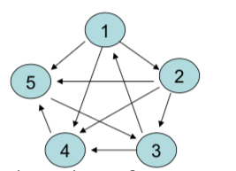

- The connectivity matrix is \[A = \left(\begin{array}{ccccc} 0 & 1 & 0 & 1 & 1\\ 0 & 0 & 1 & 1 & 1\\ 1 & 0 & 0 & 1 & 0\\ 0 & 0 & 0 & 0 & 1\\ 0 & 0 & 1 & 0 & 0 \end{array}\right)\]

## A small example

- The ranking of page \(i\) is proportional to the sum of the rankings of all pages that link to \(i\): \(r_4 = \alpha(r_1 + r_2 + r_3)\).
- So this is a system of \(n =5\) linear equations: \[r = \alpha A^T r, ~\text{or}~A^T r = (1/\alpha) r.\]
- The ranking vector is treated like a probability of relevance, so we need to then rescale so that \(\Sigma_{i=1}^n r_i = 1.\)
- Go to R and compute pageranks.

## What you need to realise for now

- Finding the eigenvalues and eigenvectors of a massive matrix is computationally challenging though (don’t try to solve the characteristic polynomial!)
- and you will learn numerical techniques later.